# Reproducible Research: Peer Assessment 1

## Loading and preprocessing the data

Unzip the archive to the current working directory and load the data into “activity” variable

```r
setwd("../RepData_peerAssessment1/")
unzip("activity.zip",exdir="./")
activity<-read.csv("activity.csv", header=TRUE, stringsAsFactors = FALSE)
activity$steps<-as.numeric(activity$steps)
activity$date<-as.Date(activity$date)
activity$interval<-as.numeric(activity$interval)
```

The first few rows of the activity data set are

```r
head(activity)
```

```
##   steps       date interval
## 1    NA 2012-10-01        0
## 2    NA 2012-10-01        5
## 3    NA 2012-10-01       10
## 4    NA 2012-10-01       15
## 5    NA 2012-10-01       20
## 6    NA 2012-10-01       25
```

## What is mean total number of steps taken per day?

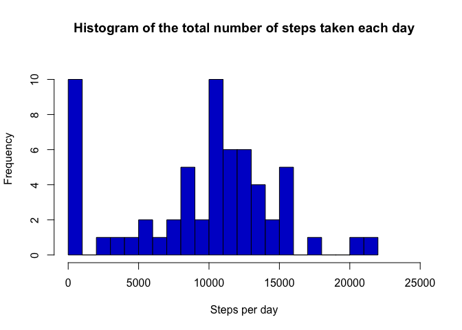

```r
s<-split(activity, activity$date)
activity_daily<-sapply(s, function(x) sum(x[,"steps"], na.rm=TRUE))
hist(activity_daily, breaks=20, main = "Histogram of the total number of steps taken each day", col="blue3", xlab = "Steps per day", xlim=c(0,25000), ylim=c(0,11))
```

Average number of steps per day is

```r
mean(activity_daily)
```

```
## [1] 9354.23
```

and the median is

```r
median(activity_daily)
```

```
## [1] 10395
```

## What is the average daily activity pattern?

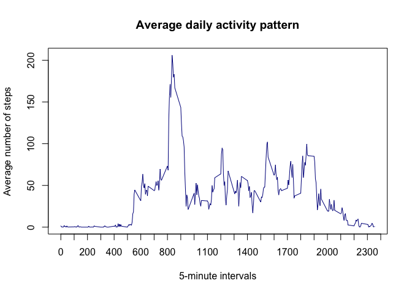

```r
activity_ints <- aggregate(steps ~ interval, activity, FUN=mean)
with(activity_ints, plot(x=interval, y=steps, type="l", main="Average daily activity pattern",xlab="5-minute intervals", ylab="Average number of steps", xaxp = c(0, 2400, 24), col="darkblue"))
```

Looking for 5-minute interval that contains the maximum number of steps on average across all the days in the dataset:

```r
i<-activity_ints[activity_ints[,"steps"]==max(activity_ints$steps),]
i
```

```
##     interval    steps
## 104      835 206.1698
```

The interval is 835 with the average number of steps 206.2.